# R Lesson 8 Creating Graphics

Kelsey Deaton

2018-09-30

Creating graphics using ggplot2

# Challenge 1

Challenge 1 Modify the example so that the figure shows how life expectancy has changed over time:

Hint: the gapminder dataset has a column called “year”, which should appear on the x-axis.

SC Example:

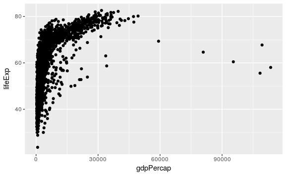

```r
library("ggplot2")
ggplot(data = gapminder, aes(x = gdpPercap, y = lifeExp)) + geom_point()
```

Modified: just change x = gdppercap to x = year

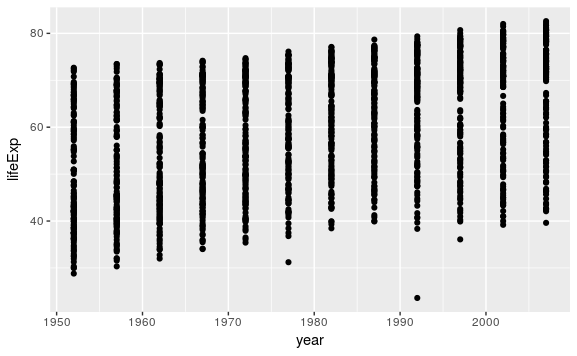

```r
ggplot(data = gapminder, aes(x = year, y = lifeExp)) + geom_point()
```

# Challenge 2

In the previous examples and challenge we’ve used the aes function to tell the scatterplot geom about the x and y locations of each point. Another aesthetic property we can modify is the point color. Modify the code from the previous challenge to color the points by the “continent” column. What trends do you see in the data? Are they what you expected?

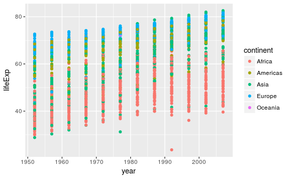

```r
ggplot(data = gapminder, aes(x = year, y = lifeExp, color = continent)) + geom_point()
```

# Layers

Can have layers of lines (geom_line) and points (geom_point)

# Challenge 3

Switch the order of the point and line layers from the previous example. What happened?

Previous example:

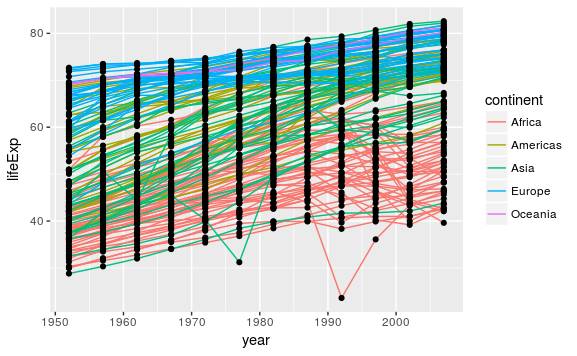

```r
ggplot(data = gapminder, aes(x=year, y=lifeExp, by=country)) +
  geom_line(aes(color=continent)) + geom_point()
```

Changed: Estimate that lines will be on top of points.

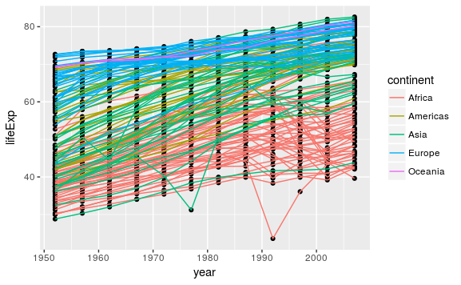

```r
ggplot(data = gapminder, aes(x=year, y=lifeExp, by=country)) +
   geom_point() + geom_line(aes(color=continent))
```

# note!

To apply an aesthetic to all points, do not use aes(). Use aes() to apply an aesthetic by variable.

Example: geom_point(color=“black”) vs geom_line(aes(color=continent))

*Note that “color” must use “”

# Transformations and statistics

Can change scale of x axis using scale()

Can make data points more transparent using alpha()

example:

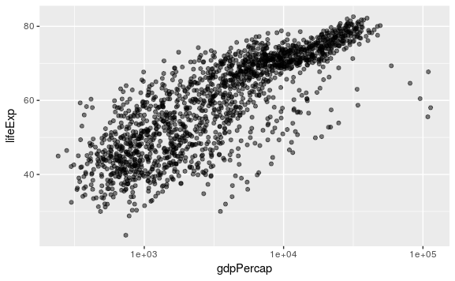

```r
ggplot(data = gapminder, aes(x = gdpPercap, y = lifeExp)) +
  geom_point(alpha = 0.5) + scale_x_log10()
```

# add a regression line with geom_smooth

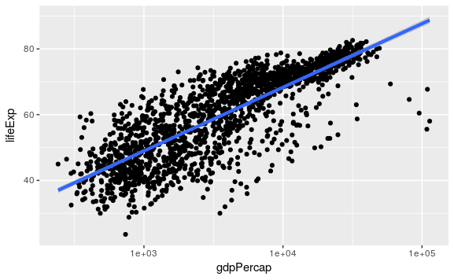

```r
? geom_smooth
ggplot(data = gapminder, aes(x = gdpPercap, y = lifeExp)) +
  geom_point() + scale_x_log10() + geom_smooth(method="lm", size=1.5)
```

# Challenge 4a

Modify the color and size of the points on the point layer in the previous example.

Hint: do not use the aes function.

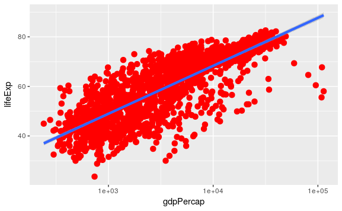

```r
ggplot(data = gapminder, aes(x = gdpPercap, y = lifeExp)) +
  geom_point(color="red", size=3) + scale_x_log10() + geom_smooth(method="lm", size=1.5)
```

# Challenge 4b

Modify your solution to Challenge 4a so that the points are now a different shape and are colored by continent with new trendlines. Hint: The color argument can be used inside the aesthetic.

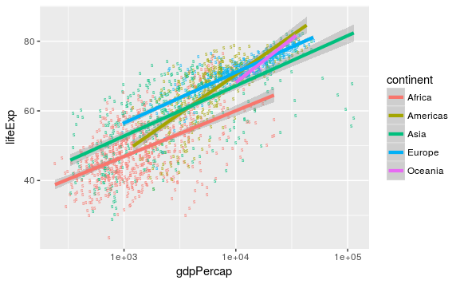

```r
ggplot(data = gapminder, aes(x = gdpPercap, y = lifeExp, color=continent)) +
  geom_point(aes(color=continent), shape="square") + scale_x_log10() + geom_smooth(method="lm", size=1.5)
```

```r
? geom_point
```

# Multi-panel figures

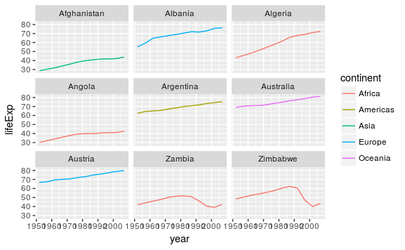

```r
starts.with <- substr(gapminder$country, start = 1, stop = 1)
az.countries <- gapminder[starts.with %in% c("A", "Z"), ]
ggplot(data = az.countries, aes(x = year, y = lifeExp, color=continent)) +
  geom_line() + facet_wrap( ~ country)
```

## Questions

Explaining the above a bit more…

```r
?facet()
```

```
Error in .helpForCall(topicExpr, parent.frame()) :
  no methods for ‘facet’ and no documentation for it as a function
```

# Text

use “labs()” function to give labels to plots

example

```r
ggplot(data = az.countries, aes(x = year, y = lifeExp, color=continent)) +
  geom_line() + facet_wrap( ~ country) +
  labs(
    x = "Year",              # x axis title
    y = "Life expectancy",   # y axis title
    title = "Figure 1",      # main title of figure
    color = "Continent"      # title of legend
  ) +
  theme(axis.text.x=element_blank(), axis.ticks.x=element_blank())
```

[output not shown]

# Exporting the plot

use ggsave()

example

```r
lifeExp_plot <- ggplot(data = az.countries, aes(x = year, y = lifeExp, color=continent)) +
  geom_line() + facet_wrap( ~ country) +
  labs(
    x = "Year",              # x axis title
    y = "Life expectancy",   # y axis title
    title = "Figure 1",      # main title of figure
    color = "Continent"      # title of legend
  ) +
  theme(axis.text.x=element_blank(), axis.ticks.x=element_blank())
ggsave(filename = "R.Lessons/graphs/lifeExp.png", plot = lifeExp_plot, width = 12, height = 10, dpi = 300, units = "cm")
```

```
Error in grid.newpage() :
  could not open file 'R.Lessons/graphs/lifeExp.png'
```

## Question

how do I save a filename this way? what are the specifics for path name

# Challenge 5

Create a density plot of GDP per capita, filled by continent.

Advanced:

Transform the x axis to better visualise the data spread. Add a facet layer to panel the density plots by year.

attempt 1:

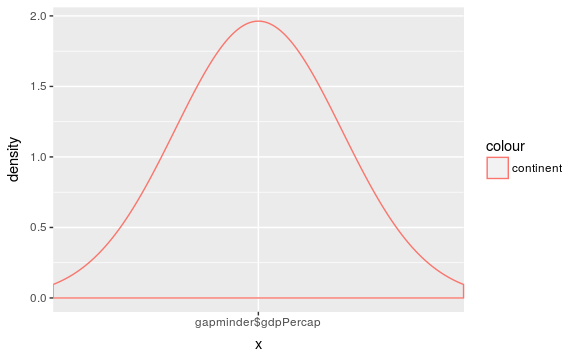

```r
density_plot = ggplot(data=gapminder, x=gapminder$gdpPercap) + geom_density(aes(x="gapminder$gdpPercap", color="continent"))
density_plot
```

SC’s answer makes no sense. Graphs look horrible.

Attempt 2, based on some of the SC answer:

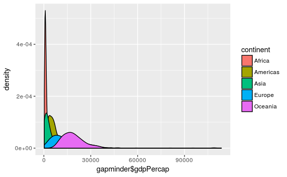

```r
density_plot = ggplot(data=gapminder, aes(x=gapminder$gdpPercap, fill=continent)) + geom_density()
density_plot
```

I’m happy with that. What if we log transform x axis?

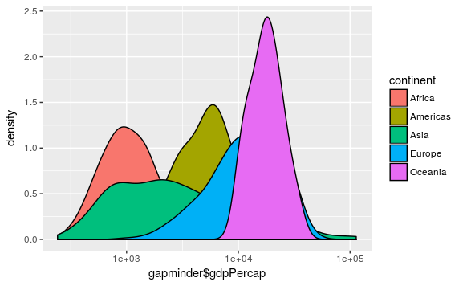

```r
density_plot = ggplot(data=gapminder, aes(x=gapminder$gdpPercap, fill=continent)) + geom_density() + scale_x_log10() #added log x axis
density_plot
```

:)